# Basic statistics for health research - week 8, ex. 1

Benjamin Skov Kaas-Hansen

15/04/2021

- https://medium.com/nautilus-magazine/pick-the-statistic-you-want-to-be-98e1ea74c4aa

# Opsætning

Hvis du skal installere en pakke (f.eks. epitools), skal du huske at køre `install.packages("epitools")` (altså navnet i citationtegn). Du skal kun installere én gang (eller hvis du har opdateret R).

```r
library(epitools)
library(broom)
library(descr)
library(plyr)
library(tidyr)
library(tidyverse)
```

```r
library(patchwork)

knitr::opts_chunk$set(fig.align = "center")
options(width = 120) # avoid wrapped output
```

## Små hjælperfunktioner

```r
pretty_estimates <- function(fit, ci_fun = confint.default) {
    # confint.default laver Wald-intervaller, mens confint laver profile-likelihood-intervaller
    bind_cols(tidy(fit), as_tibble(confint.default(fit), .name_repair = ~ c("p2.5", "p97.5"))) %>%
        select(term, estimate, p2.5, p97.5, everything())
}

pretty_coef <- function(m) { # m: model object
    cbind(Est. = m$coefficients, confint(m))
}
```

# Sandsynlighed og odds

Et par illustrationer af sammenhængen mellem hhv. sandsynlighed (p) og odds/log(odds) samt risikoratio og oddsratio. Sandsynligheder ligger mellem 0 og 1, mens grænserne for odds er 0 og $\infty$, og grænserne for log-odds er $-\infty$ og $\infty$. Det har bl.a. som konsekvens, at odds altid kan blive dobbelt så stor (eller halveres), mens det jo ikke er tilfældet for sandsynlighed (det dobbelte er f.eks. 80% ville være 160%, hvilket jo ikke giver mening for en sandsynlighed.) De stiplede linier viser sammenhængen mellem sandsynlighed og hhv. odds og log(odds), hvis den var 1:1, hvilken den tydeligvis ikke er. Jo højere sandsynlighed, des mere afgiver odds:

log(odds) derimod afviger tiltagende fra sandsynligheden des længere væk fra p = 50% vi kommer.

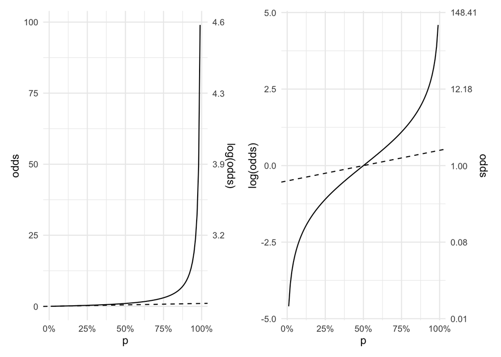

```r
d <- tibble(p = seq(0.01, 0.99, 0.01),
            odds = p / (1 - p))

p_log_odds <- ggplot(d, aes(x = p, y = log(odds))) +
    geom_line() +
    geom_abline(intercept = -0.5, slope = 1, linetype = 2) +
    scale_x_continuous(labels = scales::percent) +
    scale_y_continuous(sec.axis = sec_axis(exp, "odds", breaks = exp(-2:2*2.5), labels = scales::number_format(0.01))) +
    theme_minimal()

p_odds <- ggplot(d, aes(x = p, y = odds)) +
    geom_line() +
    geom_abline(intercept = 0, slope = 1, linetype = 2) +
    scale_x_continuous(labels = scales::percent) +
    scale_y_continuous(sec.axis = sec_axis(log, "log(odds)", breaks = log(1:4*25), labels = scales::number_format(0.1))) +
    theme_minimal()

p_odds + p_log_odds
```

Risikoratioer og oddsratioer er lidt anderledes. Ved lave sandsynligheder i kontrolgruppen, er odds ratio ret tæt på risikoratioen. Men dette ændrer sig, når sandsynliheden i kontrolgruppen stiger (bemærk logaritmiske skalaer på akserne).

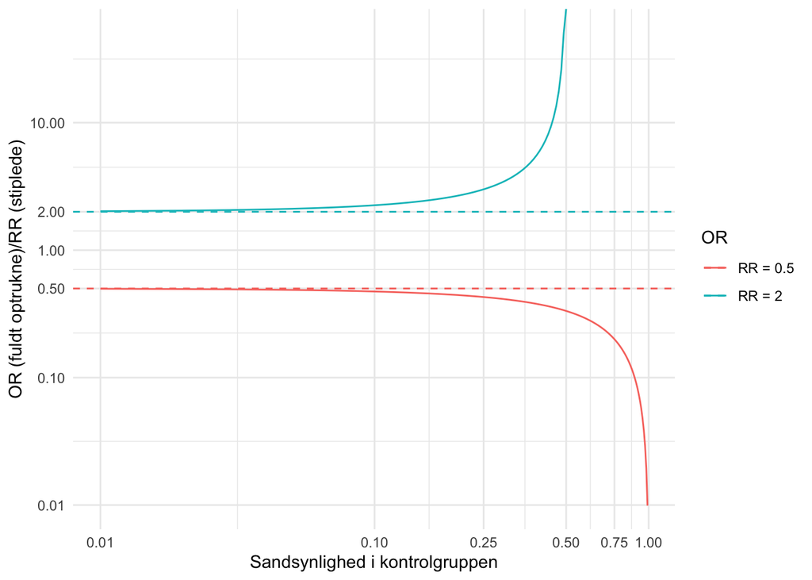

```r
tibble(p_control = seq(0.01, 0.99, 0.01),
       p_target_RR2 = p_control * 2,
       p_target_RR0.5 = p_control * 0.5,
       OR_RR2 = (p_target_RR2/(1-p_target_RR2)) / (p_control/(1-p_control)),
       OR_RR0.5 = (p_target_RR0.5/(1-p_target_RR0.5)) / (p_control/(1-p_control))) %>%
    pivot_longer(c(OR_RR2, OR_RR0.5), names_to = "OR", names_prefix = "OR_", values_to = "value") %>%
    mutate(OR = ifelse(OR == "RR2", "RR = 2", "RR = 0.5")) %>%
    filter(value > 0) %>%
    ggplot(aes(x = p_control, y = value, colour = OR)) +
        geom_line() +
        geom_hline(aes(yintercept = 2, colour = "RR = 2"), linetype = 2) +
        geom_hline(aes(yintercept = 0.5, colour = "RR = 0.5"), linetype = 2) +
        scale_y_log10(breaks = c(0.01, 0.1, 0.5, 1, 2, 10)) +
        scale_x_log10(breaks = c(0.01, 0.1, 0.25, 0.5, 0.75, 1)) +
        theme_minimal() +
        labs(x = "Sandsynlighed i kontrolgruppen", y = "OR (fuldt optrukne)/RR (stiplede)")
```

# Graft vs. host disease

## Data wrangling/manipulation

```r
graft <- read.table("http://publicifsv.sund.ku.dk/~lts/basal/data/gvhd.txt", header = TRUE) %>%
    mutate(type = factor(type, levels = 1:3, labels = c("AML", "ALL", "CML")),
           type_ALL = 1 * (type == "ALL"),
           type_CML = 1 * (type == "CML"),
           preg = factor(preg, levels = 0:1, labels = c("No", "Yes")),
           gvhd = factor(gvhd, levels = 0:1, labels = c("No", "Yes")),
           log_index = log(index),
           log2_index = log2(index)) %>%
    select(-pnr)
```

## Kig på data

Hurtigt overblik over data. Patienter ml. 13 og 43 år; aldersfordelinger ligner hinanden sandsynligvis pga. matching af donorer og modtagere.

```r
glimpse(graft) # groft overblik over data
```

```
## Rows: 37
## Columns: 10
## $ rcpage     <int> 27, 13, 19, 21, 28, 22, 19, 20, 33, 18, 17, 31, 23, 17, 26, 28, 24, 18, 24, 20, 23, 21, 21, 33, 29…
## $ donage     <int> 23, 18, 19, 22, 38, 20, 19, 23, 36, 19, 20, 21, 38, 15, 16, 25, 21, 20, 25, 24, 35, 35, 23, 43, 24…
## $ type       <fct> ALL, ALL, AML, ALL, ALL, ALL, ALL, ALL, AML, AML, ALL, CML, ALL, ALL, ALL, AML, AML, ALL, AML, CML…
## $ preg       <fct> No, No, No, No, No, No, No, No, No, No, No, No, No, No, No, No, Yes, No, Yes, No, Yes, Yes, No, No…
## $ index      <dbl> 0.27, 0.31, 0.39, 0.48, 0.49, 0.50, 0.81, 0.82, 0.86, 0.92, 1.10, 1.52, 1.88, 2.01, 2.40, 2.45, 2.…
## $ gvhd       <fct> No, No, No, No, No, No, No, No, No, No, No, No, No, No, No, No, No, No, No, No, Yes, Yes, Yes, Yes…
## $ type_ALL   <dbl> 1, 1, 0, 1, 1, 1, 1, 1, 0, 0, 1, 0, 1, 1, 1, 0, 0, 1, 0, 0, 0, 1, 0, 0, 0, 1, 0, 1, 0, 0, 0, 1, 0,…
## $ type_CML   <dbl> 0, 0, 0, 0, 0, 0, 0, 0, 0, 0, 0, 1, 0, 0, 0, 0, 0, 0, 0, 1, 0, 0, 1, 1, 1, 0, 1, 0, 0, 0, 0, 0, 1,…
## $ log_index  <dbl> -1.30933332, -1.17118298, -0.94160854, -0.73396918, -0.71334989, -0.69314718, -0.21072103, -0.1984…
## $ log2_index <dbl> -1.8889687, -1.6896599, -1.3584540, -1.0588937, -1.0291463, -1.0000000, -0.3040062, -0.2863042, -0…
```

```r
summary(graft) # overblik over fordelingen af hver variabel
```

```
##      rcpage          donage       type     preg        index         gvhd       type_ALL         type_CML
##  Min.   :13.00   Min.   :14.00   AML:11   No :27   Min.   : 0.270   No :20   Min.   :0.0000   Min.   :0.0000
##  1st Qu.:20.00   1st Qu.:20.00   ALL:16   Yes:10   1st Qu.: 0.920   Yes:17   1st Qu.:0.0000   1st Qu.:0.0000
##  Median :23.00   Median :23.00   CML:10            Median : 2.010            Median :0.0000   Median :0.0000
##  Mean   :25.43   Mean   :25.81                     Mean   : 2.556            Mean   :0.4324   Mean   :0.2703
##  3rd Qu.:29.00   3rd Qu.:34.00                     3rd Qu.: 3.730            3rd Qu.:1.0000   3rd Qu.:1.0000
##  Max.   :43.00   Max.   :43.00                     Max.   :10.110            Max.   :1.0000   Max.   :1.0000
##    log_index          log2_index
##  Min.   :-1.30933   Min.   :-1.8890
##  1st Qu.:-0.08338   1st Qu.:-0.1203
##  Median : 0.69813   Median : 1.0072
##  Mean   : 0.57221   Mean   : 0.8255
##  3rd Qu.: 1.31641   3rd Qu.: 1.8992
##  Max.   : 2.31352   Max.   : 3.3377
```

Vi skal altid tegne, før vi må regne. Måske ser det ud til, at ældre i højere grad udviklet GvHD meeen det er svært at sige noget om

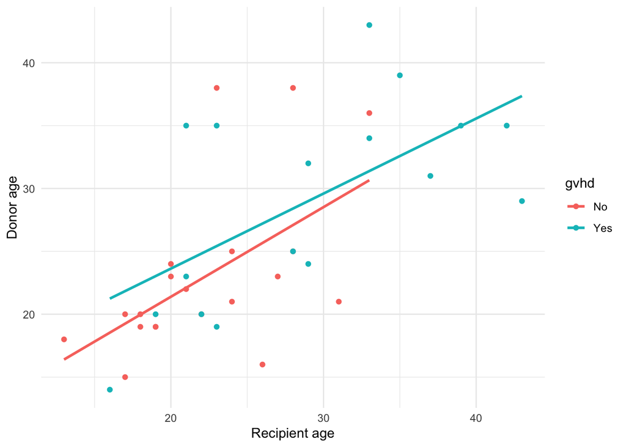

```r
ggplot(graft, aes(x = rcpage, y = donage, colour = gvhd)) +
    geom_point() +
    # geom_line() + # hvis man vil forbinde punkterne med linier (giver ikke så meget mening her)
    geom_smooth(method = "lm", se = FALSE) +
    labs(x = "Recipient age", y = "Donor age") +
    theme_minimal()
```

Med density plots ser der ikke rigtigt ud til at være nogen forskel

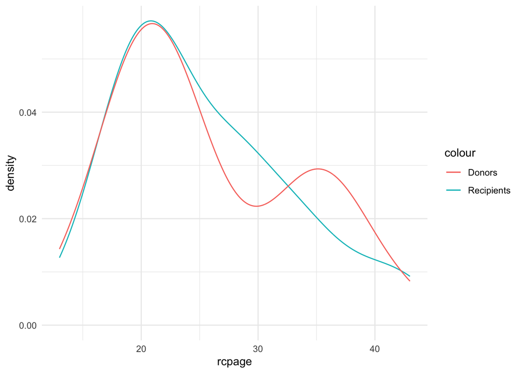

```r
ggplot(graft) +
    stat_density(aes(x = rcpage, colour = "Recipients"), geom = "line") +
    stat_density(aes(x = donage, colour = "Donors"), geom = "line") +
    theme_minimal()
```

## Spørgsmål 1

17 CvHD-cases, flest med CML. Signifikant forskel mellem frekvenser, men vi har få i hver celle, og de forventede værdier danser lidt rund om 5.

```r
CrossTable(graft$type, graft$gvhd, expected = TRUE, chisq = TRUE, fisher = TRUE, format = "SPSS",
           prop.chisq = FALSE)
```

```
##    Cell Contents
## |-------------------------|
## |                   Count |
## |         Expected Values |
## |             Row Percent |
## |          Column Percent |
## |           Total Percent |
## |-------------------------|
##
## ===================================
##               graft$gvhd
## graft$type       No     Yes   Total
## -----------------------------------
## AML              6       5      11
##                5.9     5.1
##               54.5%   45.5%   29.7%
##               30.0%   29.4%
##               16.2%   13.5%
## -----------------------------------
## ALL             12       4      16
##                8.6     7.4
##               75.0%   25.0%   43.2%
##               60.0%   23.5%
##               32.4%   10.8%
## -----------------------------------
## CML              2       8      10
##                5.4     4.6
##               20.0%   80.0%   27.0%
##               10.0%   47.1%
##                5.4%   21.6%
## -----------------------------------
## Total           20      17      37
##               54.1%   45.9%
## ===================================
##
## Statistics for All Table Factors
##
## Pearson's Chi-squared test
## ------------------------------------------------------------
## Chi^2 = 7.496952      d.f. = 2      p = 0.0236
##
##
##
## Fisher's Exact Test for Count Data
## ------------------------------------------------------------
## Alternative hypothesis: two.sided
## p = 0.0288
##         Minimum expected frequency: 4.594595
## Cells with Expected Frequency < 5: 1 of 6 (16.66667%)
```

## Spørgsmål 2

Brug `drop1()` da vi har $\geq 1$ variable (`factor`) med $\geq 2$ niveauer.

```r
fuld <- glm(gvhd ~ type + log_index + preg + donage + rcpage, data = graft, family = binomial)

summary(fuld)
```

```
##
## Call:
## glm(formula = gvhd ~ type + log_index + preg + donage + rcpage,
##     family = binomial, data = graft)
##
## Deviance Residuals:
##      Min        1Q    Median        3Q       Max
## -2.00075  -0.36457  -0.09559   0.57964   1.68281
##
## Coefficients:
##             Estimate Std. Error z value Pr(>|z|)
## (Intercept) -5.47420    2.59647  -2.108   0.0350 *
## typeALL     -0.42824    1.25389  -0.342   0.7327
## typeCML      1.61517    1.30743   1.235   0.2167
## log_index    1.81874    0.88919   2.045   0.0408 *
## pregYes      1.66236    1.18103   1.408   0.1593
## donage       0.10724    0.08262   1.298   0.1943
## rcpage       0.01597    0.08205   0.195   0.8457
## ---
## Signif. codes:  0 '***' 0.001 '**' 0.01 '*' 0.05 '.' 0.1 ' ' 1
##
## (Dispersion parameter for binomial family taken to be 1)
##
##     Null deviance: 51.049  on 36  degrees of freedom
## Residual deviance: 26.252  on 30  degrees of freedom
## AIC: 40.252
##
## Number of Fisher Scoring iterations: 6
```

```r
pretty_estimates(fuld)
```

| term | estimate | p2.5 | p97.5 | std.error | statistic | p.value |
| --- | --- | --- | --- | --- | --- | --- |
| (Intercept) | -5.47420465 | -10.56320077 | -0.3852085 | 2.59647430 | -2.1083223 | 0.03500312 |
| typeALL | -0.42824302 | -2.88581321 | 2.0293272 | 1.25388538 | -0.3415328 | 0.73270250 |
| typeCML | 1.61516852 | -0.94735423 | 4.1776913 | 1.30743359 | 1.2353733 | 0.21669161 |
| log_index | 1.81874151 | 0.07596905 | 3.5615140 | 0.88918596 | 2.0454006 | 0.04081538 |
| pregYes | 1.66235982 | -0.65242551 | 3.9771451 | 1.18103462 | 1.4075454 | 0.15926573 |
| donage | 0.10723515 | -0.05469084 | 0.2691612 | 0.08261682 | 1.2979821 | 0.19429350 |
| rcpage | 0.01596863 | -0.14484415 | 0.1767814 | 0.08204884 | 0.1946235 | 0.84568774 |

```r
drop1(fuld, test = "Chisq") # vi kan ikke se finde forskel på de tre sygdomsgruppe (p = 0.26)
```

|  | Df | Deviance | AIC | LRT | Pr(>Chi) |
| --- | --- | --- | --- | --- | --- |
|  | NA | 26.25238 | 40.25238 | NA | NA |
| type | 2 | 28.95876 | 38.95876 | 2.70637716 | 0.25841497 |
| log_index | 1 | 32.34275 | 44.34275 | 6.09036433 | 0.01359211 |
| preg | 1 | 28.44706 | 40.44706 | 2.19468112 | 0.13848787 |
| donage | 1 | 28.08156 | 40.08156 | 1.82918281 | 0.17622410 |
| rcpage | 1 | 26.29063 | 38.29063 | 0.03824513 | 0.84495173 |

```r
# drop1() bruger chi-sq til at lave likelihood-ratio test, mens summary() lavet Wald test
# library(multcomp)
# glht(fuld, linfct=matrix(c(0,0,0,1,0,0,0),1,7))
```

## Spørgsmål 3

Vi bruger `update()` så vi hele tiden kan følge med i, hvad vi laver om (og sparer en masse tegn).

```r
ud1 <- glm(gvhd ~ type + log_index + preg + donage, data = graft, family = binomial)
ud1 <- update(fuld, . ~ . - rcpage)
pretty_estimates(ud1)
```

| term | estimate | p2.5 | p97.5 | std.error | statistic | p.value |
| --- | --- | --- | --- | --- | --- | --- |
| (Intercept) | -5.2961934 | -10.01413570 | -0.5782510 | 2.40715766 | -2.2001855 | 0.02779374 |
| typeALL | -0.3967786 | -2.83194618 | 2.0383890 | 1.24245528 | -0.3193504 | 0.74946083 |
| typeCML | 1.6912754 | -0.78228984 | 4.1648406 | 1.26204627 | 1.3401057 | 0.18021099 |
| log_index | 1.8407328 | 0.10131327 | 3.5801524 | 0.88747527 | 2.0741230 | 0.03806789 |
| pregYes | 1.7218653 | -0.52294151 | 3.9666722 | 1.14533065 | 1.5033784 | 0.13274150 |
| donage | 0.1135250 | -0.03555216 | 0.2626021 | 0.07606116 | 1.4925486 | 0.13555538 |

```r
drop1(ud1, test = "Chisq")
```

|  | Df | Deviance | AIC | LRT | Pr(>Chi) |
| --- | --- | --- | --- | --- | --- |
|  | NA | 26.29063 | 38.29063 | NA | NA |
| type | 2 | 29.40322 | 37.40322 | 3.112593 | 0.21091579 |
| log_index | 1 | 32.63035 | 42.63035 | 6.339727 | 0.01180631 |
| preg | 1 | 28.81241 | 38.81241 | 2.521786 | 0.11228331 |
| donage | 1 | 28.83174 | 38.83174 | 2.541115 | 0.11091642 |

```r
# Use explicitly the type variables, make new fuld model (= combine ALL and AML groups, i.e. the acute types)
# drop1 no longer needed because no covariates have several levels (i.e. no factors)
fuld1 <- glm(gvhd ~ type_ALL + type_CML + log_index + preg + donage + rcpage, data = graft, family = binomial)
pretty_estimates(fuld1)
```

| term | estimate | p2.5 | p97.5 | std.error | statistic | p.value |
| --- | --- | --- | --- | --- | --- | --- |
| (Intercept) | -5.47420465 | -10.56320077 | -0.3852085 | 2.59647430 | -2.1083223 | 0.03500312 |
| type_ALL | -0.42824302 | -2.88581321 | 2.0293272 | 1.25388538 | -0.3415328 | 0.73270250 |
| type_CML | 1.61516852 | -0.94735423 | 4.1776913 | 1.30743359 | 1.2353733 | 0.21669161 |
| log_index | 1.81874151 | 0.07596905 | 3.5615140 | 0.88918596 | 2.0454006 | 0.04081538 |
| pregYes | 1.66235982 | -0.65242551 | 3.9771451 | 1.18103462 | 1.4075454 | 0.15926573 |
| donage | 0.10723515 | -0.05469084 | 0.2691612 | 0.08261682 | 1.2979821 | 0.19429350 |
| rcpage | 0.01596863 | -0.14484415 | 0.1767814 | 0.08204884 | 0.1946235 | 0.84568774 |

```r
ud1 <- update(fuld1, . ~ . - rcpage)
pretty_estimates(ud1)
```

| term | estimate | p2.5 | p97.5 | std.error | statistic | p.value |
| --- | --- | --- | --- | --- | --- | --- |
| (Intercept) | -5.2961934 | -10.01413570 | -0.5782510 | 2.40715766 | -2.2001855 | 0.02779374 |
| type_ALL | -0.3967786 | -2.83194618 | 2.0383890 | 1.24245528 | -0.3193504 | 0.74946083 |
| type_CML | 1.6912754 | -0.78228984 | 4.1648406 | 1.26204627 | 1.3401057 | 0.18021099 |
| log_index | 1.8407328 | 0.10131327 | 3.5801524 | 0.88747527 | 2.0741230 | 0.03806789 |
| pregYes | 1.7218653 | -0.52294151 | 3.9666722 | 1.14533065 | 1.5033784 | 0.13274150 |
| donage | 0.1135250 | -0.03555216 | 0.2626021 | 0.07606116 | 1.4925486 | 0.13555538 |

```r
summary(ud1)
```

```
##
## Call:
## glm(formula = gvhd ~ type_ALL + type_CML + log_index + preg +
##     donage, family = binomial, data = graft)
##
## Deviance Residuals:
##      Min        1Q    Median        3Q       Max
## -2.05229  -0.36206  -0.09068   0.62322   1.66401
##
## Coefficients:
##             Estimate Std. Error z value Pr(>|z|)
## (Intercept) -5.29619    2.40716  -2.200   0.0278 *
## type_ALL    -0.39678    1.24246  -0.319   0.7495
## type_CML     1.69128    1.26205   1.340   0.1802
## log_index    1.84073    0.88748   2.074   0.0381 *
## pregYes      1.72187    1.14533   1.503   0.1327
## donage       0.11352    0.07606   1.493   0.1356
## ---
## Signif. codes:  0 '***' 0.001 '**' 0.01 '*' 0.05 '.' 0.1 ' ' 1
##
## (Dispersion parameter for binomial family taken to be 1)
##
##     Null deviance: 51.049  on 36  degrees of freedom
## Residual deviance: 26.291  on 31  degrees of freedom
## AIC: 38.291
##
## Number of Fisher Scoring iterations: 6
```

```r
ud2 <- update(ud1, . ~ . - type_ALL)
pretty_estimates(ud2) # note that now the effect of type_CML is vs. both AML and ALL (before they were pairwise)
```

| term | estimate | p2.5 | p97.5 | std.error | statistic | p.value |
| --- | --- | --- | --- | --- | --- | --- |
| (Intercept) | -5.412093 | -9.99383114 | -0.8303539 | 2.33766471 | -2.315171 | 0.02060360 |
| type_CML | 1.870208 | -0.36833522 | 4.1087518 | 1.14213502 | 1.637467 | 0.10153295 |
| log_index | 1.897220 | 0.19758581 | 3.5968540 | 0.86717619 | 2.187814 | 0.02868318 |
| pregYes | 1.734594 | -0.51645579 | 3.9856441 | 1.14851598 | 1.510292 | 0.13096901 |
| donage | 0.109224 | -0.03490989 | 0.2533579 | 0.07353905 | 1.485252 | 0.13747714 |

```r
mod1 <- update(ud2, . ~ . - type_CML)
mod2 <- update(ud2, . ~ . - preg)
mod3 <- update(ud2, . ~ . - donage)

ldply(list(mod1 = mod1, mod2 = mod2, mod3 = mod3), pretty_estimates)
```

| .id | term | estimate | p2.5 | p97.5 | std.error | statistic | p.value |
| --- | --- | --- | --- | --- | --- | --- | --- |
| mod1 | (Intercept) | -5.2586709 | -9.440342975 | -1.0769989 | 2.13354536 | -2.464757 | 0.013710619 |
| mod1 | log_index | 2.1060387 | 0.493508783 | 3.7185687 | 0.82273447 | 2.559804 | 0.010473131 |
| mod1 | pregYes | 1.2912468 | -0.727829826 | 3.3103234 | 1.03016007 | 1.253443 | 0.210044574 |
| mod1 | donage | 0.1245280 | -0.004414622 | 0.2534706 | 0.06578825 | 1.892860 | 0.058376426 |
| mod2 | (Intercept) | -5.8530354 | -10.287246363 | -1.4188243 | 2.26239413 | -2.587098 | 0.009678806 |
| mod2 | type_CML | 1.5142354 | -0.600095333 | 3.6285661 | 1.07875997 | 1.403681 | 0.160413729 |
| mod2 | log_index | 2.0591712 | 0.436128922 | 3.6822134 | 0.82809800 | 2.486627 | 0.012896038 |
| mod2 | donage | 0.1487655 | 0.012776637 | 0.2847543 | 0.06938334 | 2.144110 | 0.032024107 |
| mod3 | (Intercept) | -2.5464183 | -4.405517795 | -0.6873189 | 0.94853756 | -2.684573 | 0.007262251 |
| mod3 | type_CML | 2.2505626 | 0.082755356 | 4.4183697 | 1.10604440 | 2.034785 | 0.041872512 |

[output cut: 2 more lines]

```r
    # for all three, at least one other covariate becomes significant
```

Hvis vi havde fjernet `type` ovenfor i stedet for at dele den op, var vi kommet frem til et andet resultat.

```r
try1 <- update(fuld, . ~ . - rcpage - type)
summary(try1) # læg mærke til, at denne faktisk er mage til mod1 ovenfor
```

```
##
## Call:
## glm(formula = gvhd ~ log_index + preg + donage, family = binomial,
##     data = graft)
##
## Deviance Residuals:
##     Min       1Q   Median       3Q      Max
## -2.0395  -0.5230  -0.1074   0.6282   1.8942
##
## Coefficients:
##             Estimate Std. Error z value Pr(>|z|)
## (Intercept) -5.25867    2.13355  -2.465   0.0137 *
## log_index    2.10604    0.82273   2.560   0.0105 *
## pregYes      1.29125    1.03016   1.253   0.2100
## donage       0.12453    0.06579   1.893   0.0584 .
## ---
## Signif. codes:  0 '***' 0.001 '**' 0.01 '*' 0.05 '.' 0.1 ' ' 1
##
## (Dispersion parameter for binomial family taken to be 1)
##
##     Null deviance: 51.049  on 36  degrees of freedom
## Residual deviance: 29.403  on 33  degrees of freedom
## AIC: 37.403
##
## Number of Fisher Scoring iterations: 6
```

```r
try2 <- update(try1, . ~ . - preg)
summary(try2)
```

```
##
## Call:
## glm(formula = gvhd ~ log_index + donage, family = binomial, data = graft)
##
## Deviance Residuals:
##     Min       1Q   Median       3Q      Max
## -1.8298  -0.6412  -0.1189   0.6440   1.7503
##
## Coefficients:
##             Estimate Std. Error z value Pr(>|z|)
## (Intercept) -5.45399    2.08147  -2.620  0.00879 **
## log_index    2.17773    0.78986   2.757  0.00583 **
## donage       0.14594    0.06465   2.257  0.02399 *
## ---
## Signif. codes:  0 '***' 0.001 '**' 0.01 '*' 0.05 '.' 0.1 ' ' 1
##
## (Dispersion parameter for binomial family taken to be 1)
##
##     Null deviance: 51.049  on 36  degrees of freedom
## Residual deviance: 31.068  on 34  degrees of freedom
## AIC: 37.068
##
## Number of Fisher Scoring iterations: 5
```

## Spørgsmål 4

```r
exp(pretty_coef(mod3))
```

```
##                    Est.       2.5 %      97.5 %
## (Intercept)  0.07836183 0.007712384   0.3584982
## type_CML     9.49307468 1.256305406 109.1452495
## log_index    4.42699116 1.288578179  24.2894317
## pregYes     12.12781735 1.666952110 141.9878238
```

## Spørgsmål 5

```r
slut_model <- update(mod3, . ~ . - log_index + log2_index)
round(exp(pretty_coef(slut_model)), 2) # en fordobling i index øger odds 2.8 gange
```

```
##              Est. 2.5 % 97.5 %
## (Intercept)  0.08  0.01   0.36
## type_CML     9.49  1.26 109.15
## pregYes     12.13  1.67 141.99
## log2_index   2.80  1.19   9.13
```

### Prædiktere risiko for forskellige værdier af `log2_index`

Vi gør brug af `expand.grid` hvilket laver alle kombinationer af vektorerne, du giver som input. Virkeligt god til denne slags opgaver, hvor du skal lave prædiktioner for mange variable (kaldes grid search).

Linierne inden for hvert panel er (nok) parallelle på log(odds)-skalaen, men linierne er tegnet på sandsynlighedsskalaen (som vi faktisk er interesserede i), hvorfor de ikke er parallelle her i “klassisk” forstand. Kurverne er dog forskellige for donorer, der har været gravide, og donorer, der ikke har, hvilket kunne tyde på en interaktion mellem `index` og `preg`.

```r
pred_data <- expand.grid(log2_index = seq(-1, 3.3, 0.1),
                         type_CML = 0:1,
                         preg = c("No", "Yes")) %>%
    bind_cols(pred = predict(slut_model, newdata = ., type = "response")) %>%
    mutate(index = 2^log2_index, # tilbagetransformer
           type = ifelse(type_CML == 1, "Kronisk", "Akut"))
pred_data # første 3 kolonner af alle kombinationer, 4. kolonner er prædiktionerne for hver kombination,
```

| log2_index | type_CML | preg | pred | index | type |
| --- | --- | --- | --- | --- | --- |
| -1.0 | 0 | No | 0.02718239 | 0.5000000 | Akut |
| -0.9 | 0 | No | 0.03004637 | 0.5358867 | Akut |
| -0.8 | 0 | No | 0.03320180 | 0.5743492 | Akut |
| -0.7 | 0 | No | 0.03667609 | 0.6155722 | Akut |
| -0.6 | 0 | No | 0.04049870 | 0.6597540 | Akut |
| -0.5 | 0 | No | 0.04470124 | 0.7071068 | Akut |
| -0.4 | 0 | No | 0.04931746 | 0.7578583 | Akut |
| -0.3 | 0 | No | 0.05438326 | 0.8122524 | Akut |
| -0.2 | 0 | No | 0.05993659 | 0.8705506 | Akut |
| -0.1 | 0 | No | 0.06601741 | 0.9330330 | Akut |

[output cut: 166 more lines]

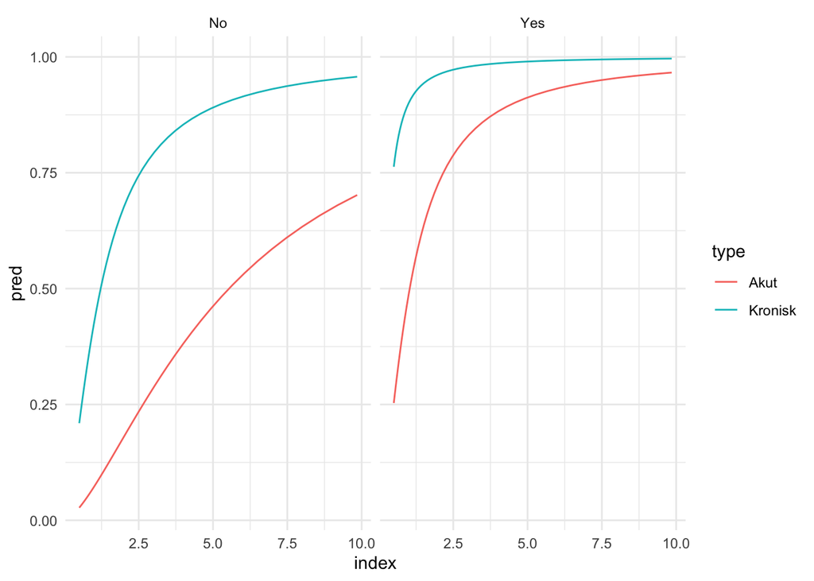

```r
    # 5. kolonner er index (tilbageregnet fra log2_index), 6. kolonne er bare en pæn indikator til plottet

ggplot(pred_data, aes(x = index, y = pred, colour = type)) +
    geom_line() +
    facet_wrap(~ preg) +
    theme_minimal()
```

## Spørgsmål 6

Så vi prøver at tilføje en interaktion, som faktisk har en p-værdi omkring 9%.

```r
int <- update(slut_model, . ~ . + log2_index:preg)
summary(int)
```

```
##
## Call:
## glm(formula = gvhd ~ type_CML + preg + log2_index + preg:log2_index,
##     family = binomial, data = graft)
##
## Deviance Residuals:
##      Min        1Q    Median        3Q       Max
## -2.41155  -0.27268  -0.05696   0.44911   1.28816
##
## Coefficients:
##                    Estimate Std. Error z value Pr(>|z|)
## (Intercept)         -3.5104     1.4643  -2.397   0.0165 *
## type_CML             2.5028     1.2661   1.977   0.0481 *
## pregYes              6.3005     2.8768   2.190   0.0285 *
## log2_index           1.7238     0.8507   2.026   0.0427 *
## pregYes:log2_index  -2.8780     1.7085  -1.684   0.0921 .
## ---
## Signif. codes:  0 '***' 0.001 '**' 0.01 '*' 0.05 '.' 0.1 ' ' 1
##
## (Dispersion parameter for binomial family taken to be 1)
##
##     Null deviance: 51.049  on 36  degrees of freedom
## Residual deviance: 24.848  on 32  degrees of freedom
## AIC: 34.848
##
## Number of Fisher Scoring iterations: 6
```

```r
pretty_estimates(int)
```

| term | estimate | p2.5 | p97.5 | std.error | statistic | p.value |
| --- | --- | --- | --- | --- | --- | --- |
| (Intercept) | -3.510411 | -6.38035025 | -0.6404708 | 1.4642819 | -2.397360 | 0.01651370 |
| type_CML | 2.502751 | 0.02125881 | 4.9842432 | 1.2660907 | 1.976755 | 0.04806934 |
| pregYes | 6.300544 | 0.66210706 | 11.9389811 | 2.8768064 | 2.190117 | 0.02851572 |
| log2_index | 1.723834 | 0.05655045 | 3.3911183 | 0.8506707 | 2.026441 | 0.04271956 |
| pregYes:log2_index | -2.878010 | -6.22666948 | 0.4706504 | 1.7085314 | -1.684493 | 0.09208639 |

```r
# Little trick to get the effect of the interaction is to take out the main effect (significance should be determined before)
int2 <- update(int, . ~ . - log2_index)
exp(pretty_coef(int2)) # the effect of index seems opposite for patient with and without previous pregnancies (albeit non-significant)
```

```
##                            Est.        2.5 %       97.5 %
## (Intercept)          0.02988464 0.0005364857 2.505458e-01
## type_CML            12.21605402 1.3345076061 2.594046e+02
## pregYes            544.86828442 6.8056809676 1.720470e+06
## pregNo:log2_index    5.60598270 1.6126269770 5.976259e+01
## pregYes:log2_index   0.31531752 0.0055253095 3.527806e+00
```